# Guía 01: Metrología y unidades de medida

## 1. Introducción a la Metrología

**¿Qué es la Metrología?** La metrología es la ciencia que se ocupa de las mediciones y sus aplicaciones. Es fundamental en la industria y en la vida cotidiana, ya que garantiza la uniformidad y precisión en las mediciones, permitiendo la correcta fabricación de productos y la coherencia en el comercio y la ciencia.

**Importancia en la Industria y la Vida Cotidiana** En la industria, la metrología asegura que las piezas y productos cumplan con especificaciones exactas, lo que es esencial para la calidad y seguridad. En la vida diaria, las mediciones precisas son cruciales en áreas como la salud (dosificación de medicamentos), el comercio (pesos y medidas de productos) y la construcción (dimensiones de estructuras)

**Breve Historia y Evolución** La necesidad de medir con precisión ha existido desde las antiguas civilizaciones. Con el tiempo, se han desarrollado sistemas de unidades estandarizados, como el Sistema Internacional de Unidades (SI), para unificar las mediciones a nivel global.

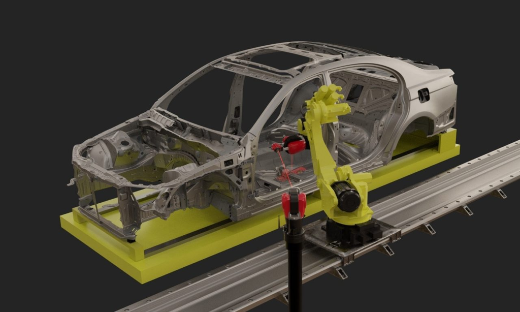

Fuente: apimetrology.com. El control de medidas en la estructura portante de un auto es crítica para su calidad y perfomance./

**Actividad 1:** Observa este [video](https://www.youtube.com/watch?v=U0Ho018Ksic) y responde estas preguntas:

- **a)** ¿En qué aspectos se centra la metrología dimensional?
- **b)** Explicar en 3 renglones y con un ejemplo la relación entre la metrología y la justicia (y legalidad)
- **c)** ¿En qué usas la metrología en tu vida diaria?

## 2. Sistema Métrico Legal Argentino (SIMELA)

**¿Qué es el SIMELA?** El Sistema Métrico Legal Argentino (SIMELA) es el sistema de unidades de medida vigente en Argentina, de uso obligatorio y exclusivo en todos los actos públicos y privados. Está constituido por las unidades, múltiplos, submúltiplos, prefijos y símbolos del Sistema Internacional de Unidades (SI), así como por algunas unidades ajenas al SI que se incorporan para satisfacer requisitos específicos.

**Relación con el Sistema Internacional de Unidades (SI)** El SIMELA adopta las siete unidades base del SI, que son:

- **Longitud**: metro [m]
- **Masa**: kilogramo [Kg]
- **Tiempo**:segundo [s]
- **Intensidad de corriente eléctrica**: ampere [A]
- **Temperatura**: kelvin [k]
- **Cantidad de sustancia**:mol [mol]
- **Intensidad luminosa**: candela [cd]

**Actividad 2:** Investiga y nombra algunas unidades (al menos tres) que están en el SIMELA por tradición o utilidad y no están en el SI.

## 3. Sistema Inglés o Anglosajón

El Sistema Inglés, también conocido como Sistema Imperial o Anglosajón, se originó en Inglaterra y todavía se utiliza en algunos países, como Estados Unidos. Aunque su uso ha disminuido en favor del SI, aún es relevante en ciertos sectores industriales y comercials.

**Actividad 3:** Reescribir las unidades de abajo poniendo el valor de la equivalencia en los puntos suspensivos:

- **Longitud**
  - 1 Pulgada = … milímetros
  - 1 pie = … milímetros
- **Fuerza**:
  - 1 Onza-fuerza = … Newton = … Kgf (kilogramo fuerza)
  - 1 Libra-fuerza = … Newton = … Kgf
- **Volumen**:
  - 1 Galón = … litros
- **Presión**:
  - 1 Libra por pulgada cuadrada [PSI] = … Pa (Pascales) = … bares

**Actividad 4:** En el siguiente texto reemplazar las líneas “____” por el número que corresponde según la equivalencia:

> Según este [video](https://www.youtube.com/watch?v=knRgcLQbV_w) en el año 2002 a un Boeing 737 de la Aerolínea Garuda Indonesia, que vuela a 28.000 pies (es decir a ____ metros) se le apagan ambos motores cuando esta atravezando una tormenta de gran intensiad. La gran acumulación de agua y granizo apaga la combustión del motor y no permite re-encenderlo. Además se suma una falla eléctrica que deja al avión sin comandos hidráulicos y sin comunicación. Los pilotos tienen que maniobrar manualmente haciendo mucha fuerza para controlar el avión que baja planeando a razón de 4000 pies por minuto (es decir a razón de ____ metros por minuto). Cuando están cerca de la tierra las nubes se depejan y pueden ver que su mejor opción es aterrizar en un río no muy profundo. Finalmente lo logran salvando a casi todas las personas. Normalmente este avión carga 6870 galones (____ litros) de combustible y este, en situación de emergencia, se tira antes de aterrizar pero aquí esto no se hizo probablemente por que el aterrizaje era sobre agua. Otro dato de estos aviones es que las cubiertas traseras del tren de aterrizaje se inflan a una presión de 200 PSI (es decir ____ bares) y las delanteras entre 120-130 PSI (es decir ____ - ____ bares). Esto es así por que las traseras tocan primero el piso y sufren el mayor impacto. De todos modos en este aterrizaje de emergencia sobre agua no se bajó, naturalmente, ningún tren de aterrizaje.